# Final Project on LANDSAT 8 in R

David Goldsmith

2023-02-02

In this final project, I wanted to repeat a similar analysis we performed in GEOG0150. The goal was to load different bands and band combinations to look at the makeup of the Middlebury area.

I chose to go this route because I was curious how other programs compare to Google Earth Engine, which I learned in GEOG0150. I had initially intended to compare NDVI values to median household income by census tract, but I found that R is a somewhat complicated software to do this on. Instead, this final project demonstrated how to install and load LANDSAT data, and how it can be used in R.

[This website](https://michaelminn.net/tutorials/r-landsat/index.html), written by Michael Minn was particularly helpful in my work.

### Importing Data

1. Make an account with USGS.
2. Through [EarthExplorer](https://earthexplorer.usgs.gov/), filter data.
- For location, use the polygon section to navigate to the area of study. Mine was a point in Middlebury.
- Select a data range. For NDVI, it’s best to choose summer months (when plants have the most vegetation).
- Select your data set. I chose Landsat > Collection 2 Level 1.
- on the bottom of the page, select “Results”.
3. Open the files for data sets with the fewest clouds.
4. Download the “product bundle”, or select bands of choice. I downloaded those for natural color, red, nir.
5. Move these files to your project locally.

### Install Packages

```r
library(raster)
```

```r
library(ggplot2)
```

### Creating the Plots

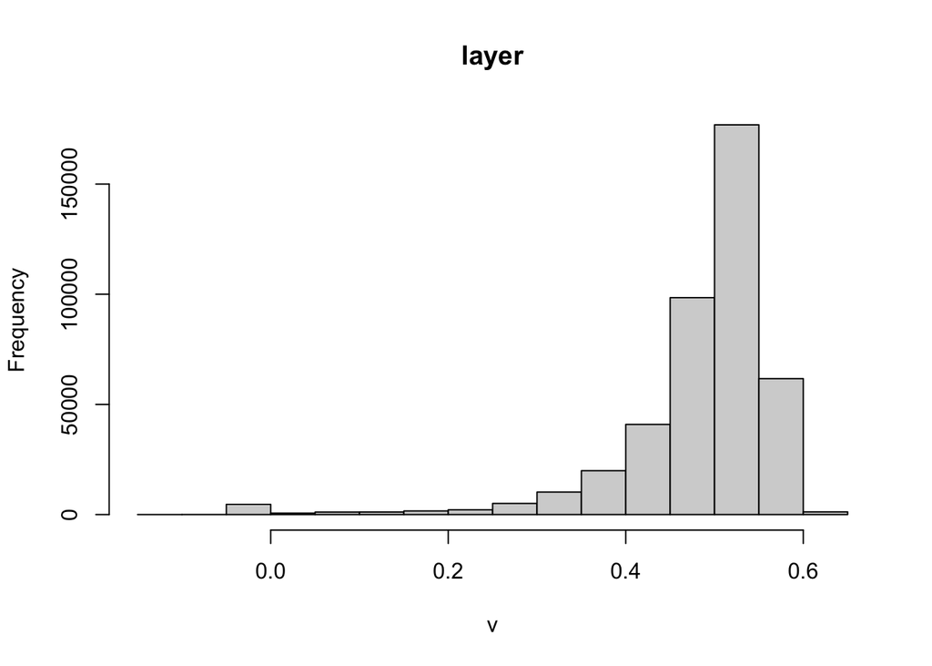

```r
## Load in your bands
redVT = raster("finalData/redVermontBand.TIF")
near.infraredVT = raster("finalData/nirVermontBand.TIF")
shortWave1 = raster("finalData/sw_ir_1.TIF")
shortWave2 = raster("finalData/sw_ir_2.TIF")

## Set boundaries (limit the area displayed)
boundary = raster(ymx=44.056, xmn=-73.215, ymn=43.85, xmx=-73.016)

#### NDVI plot
boundary_ndvi = projectExtent(boundary, redVT@crs)

red = crop(redVT, boundary_ndvi)
near.infraredVT = crop(near.infraredVT, boundary_ndvi)

# Perform band math to obtain NDVI values in the raster
ndvi = (near.infraredVT - redVT) / (near.infraredVT + redVT)
## ^ This yields an error, but so far does not impact final result

# Use a histogram to determine which values to limit for
hist(ndvi)
```

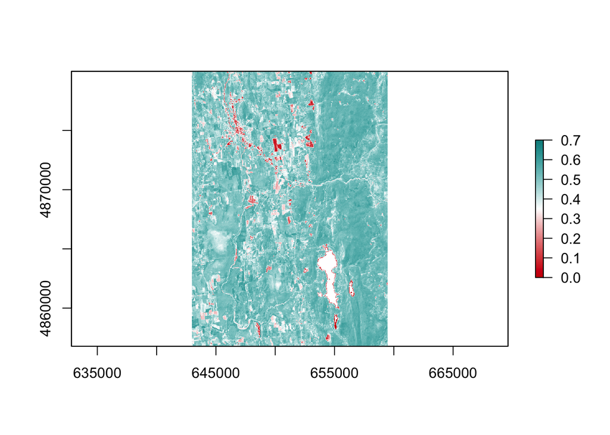

```r
## Although values below 0 exist, I excluded them to avoid confusion. These points are spots of water.

# Set a color palatte
colors = colorRampPalette(c("red3", "white", "darkcyan"))(255)

ndvi_plot <- plot(ndvi, zlim=c(0, 0.7), col=colors)
```

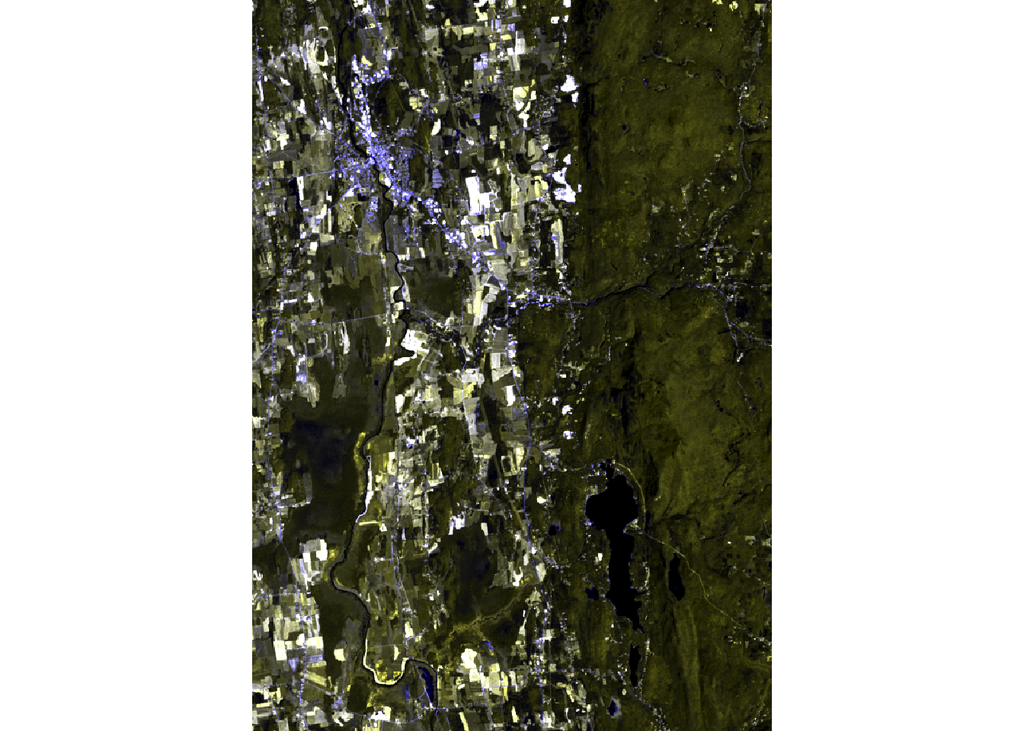

```r
#### Short-wave Infrared Plots

# Use the stack feature to blend the necessary bands
swir = stack(shortWave2, shortWave2, redVT)

# Modify the boundary
boundary_swir = projectExtent(boundary, swir@crs)

# Crop the boundary to the swir data
swir_crop = crop(swir, boundary_swir)

# Like before, plot the model. However, make sure "plotRGB" is used.
swir_plot <- plotRGB(swir_crop, scale=65535, stretch="lin")
```

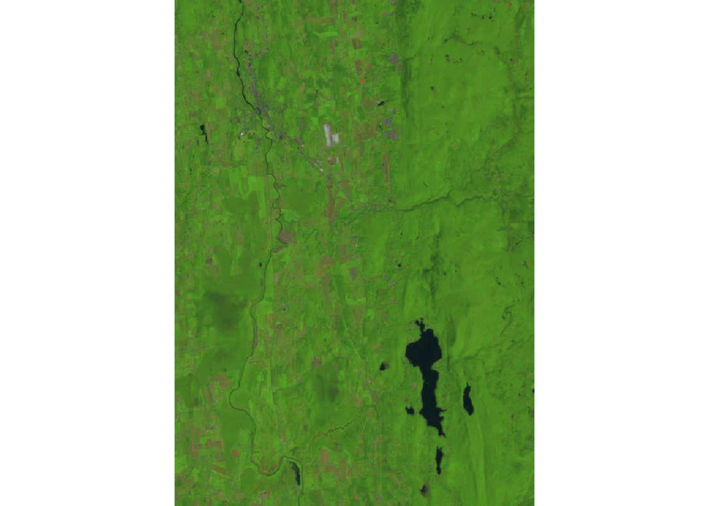

```r
#### Natural Color Plot

# load the band, but instead of raster(), use brick(). The file already contains layered bands
allNatty = brick("nattyData.tif")

# build a boundary
boundary_allNatty = projectExtent(boundary, allNatty@crs)

# apply the boundary to the band
allNatty_cropped = crop(allNatty, boundary_allNatty)

# as with swir, use plotRGB()
natty_plot <- plotRGB(allNatty_cropped)
```

# So what do these colors mean?

## NDVI

Low NDVI numbers (red) indicate no/low vegetation, while high values (blue) indicate lots of healthy vegetation. Starkly white areas are often water sources. (Can you spot Lake Dunmore?)

## Natural Color

As it sounds.

### Final Notes and Going Beyond

Most of my issues in comparing LANDSAT data to census data came from trouble with accessing the right files; the raster package reads geoJson files, not commonly found shp files.